`r messy <- read_excel("Datos_Proyecto.xlsx") Datos_Proyecto$Seasons <- as.factor(Datos_Proyecto$Seasons) Datos_Proyecto$time <- as.factor(Datos_Proyecto$time) summary(Datos_Proyecto)`

`## Seasons time Chla Chlc Car ## Autumn:27 day 1:36 Min. :0.6730 Min. :0.01000 Min. :0.4190 ## Spring:27 day 2:36 1st Qu.:0.9888 1st Qu.:0.06775 1st Qu.:0.6240 ## Summer:27 day 3:36 Median :1.1660 Median :0.09500 Median :0.7520 ## Winter:27 Mean :1.1856 Mean :0.09365 Mean :0.7557 ## 3rd Qu.:1.3813 3rd Qu.:0.10975 3rd Qu.:0.8780 ## Max. :1.9690 Max. :0.22100 Max. :1.2080 ## PC DPPH Temperature pH ## Min. : 4.600 Min. : 3.792 Min. :11.54 Min. :7.620 ## 1st Qu.: 9.953 1st Qu.: 6.539 1st Qu.:12.47 1st Qu.:7.850 ## Median :13.815 Median : 7.769 Median :13.29 Median :7.960 ## Mean :15.153 Mean : 7.444 Mean :14.08 Mean :7.982 ## 3rd Qu.:18.990 3rd Qu.: 8.433 3rd Qu.:15.35 3rd Qu.:8.150 ## Max. :37.340 Max. :10.097 Max. :18.02 Max. :8.500 ## Salinity PAR ## Min. :16.44 Min. : 9.768 ## 1st Qu.:29.62 1st Qu.: 196.000 ## Median :34.10 Median : 525.793 ## Mean :30.49 Mean : 569.983 ## 3rd Qu.:34.63 3rd Qu.: 764.500 ## Max. :34.90 Max. :1921.000`

`r summary(messy)`

`## Seasons time Chla Chlc ## Length:108 Length:108 Min. :0.6730 Min. :0.01000 ## Class :character Class :character 1st Qu.:0.9888 1st Qu.:0.06775 ## Mode :character Mode :character Median :1.1660 Median :0.09500 ## Mean :1.1856 Mean :0.09365 ## 3rd Qu.:1.3813 3rd Qu.:0.10975 ## Max. :1.9690 Max. :0.22100 ## Car PC DPPH Temperature ## Min. :0.4190 Min. : 4.600 Min. : 3.792 Min. :11.54 ## 1st Qu.:0.6240 1st Qu.: 9.953 1st Qu.: 6.539 1st Qu.:12.47 ## Median :0.7520 Median :13.815 Median : 7.769 Median :13.29 ## Mean :0.7557 Mean :15.153 Mean : 7.444 Mean :14.08 ## 3rd Qu.:0.8780 3rd Qu.:18.990 3rd Qu.: 8.433 3rd Qu.:15.35 ## Max. :1.2080 Max. :37.340 Max. :10.097 Max. :18.02 ## pH Salinity PAR ## Min. :7.620 Min. :16.44 Min. : 9.768 ## 1st Qu.:7.850 1st Qu.:29.62 1st Qu.: 196.000 ## Median :7.960 Median :34.10 Median : 525.793 ## Mean :7.982 Mean :30.49 Mean : 569.983 ## 3rd Qu.:8.150 3rd Qu.:34.63 3rd Qu.: 764.500 ## Max. :8.500 Max. :34.90 Max. :1921.000`

## 9. Proponer hipótesis y realiza análisis estadístico de los datos, incluye evaluación de supuestos si corresponde

Hipótesis Nula: Existe una estructura de grupos separados por las variables categoricas estacionalidad y día. Hipótesis alternativa: No existe una estructura de grupos separados por las variables categoricas estacionalidad y día.

`r library(readxl) library(ggplot2) library(dplyr) library(knitr) library(pander) library(psych) # Graficas de correlación library(factoextra) # distancia euclideana`

`## Welcome! Want to learn more? See two factoextra-related books at https://goo.gl/ve3WBa`

`r library(vegan) # Community Ecology Package: Ordination, Diversity and Dissimilarities`

`## Loading required package: permute`

`## Loading required package: lattice`

`## This is vegan 2.6-4`

`r library(dendextend) # extiende opciones de visualización`

`## Registered S3 method overwritten by 'dendextend': ## method from ## rev.hclust vegan`

`## ## Attaching package: 'dendextend'`

`## The following object is masked from 'package:permute': ## ## shuffle`

`## The following object is masked from 'package:stats': ## ## cutree`

# Importar datos proyecto.

`r datos_PCA <- read_excel("Datos_Proyecto.xlsx", sheet = 1) summary(datos_PCA)`

`## Seasons time Chla Chlc ## Length:108 Length:108 Min. :0.6730 Min. :0.01000 ## Class :character Class :character 1st Qu.:0.9888 1st Qu.:0.06775 ## Mode :character Mode :character Median :1.1660 Median :0.09500 ## Mean :1.1856 Mean :0.09365 ## 3rd Qu.:1.3813 3rd Qu.:0.10975 ## Max. :1.9690 Max. :0.22100 ## Car PC DPPH Temperature ## Min. :0.4190 Min. : 4.600 Min. : 3.792 Min. :11.54 ## 1st Qu.:0.6240 1st Qu.: 9.953 1st Qu.: 6.539 1st Qu.:12.47 ## Median :0.7520 Median :13.815 Median : 7.769 Median :13.29 ## Mean :0.7557 Mean :15.153 Mean : 7.444 Mean :14.08 ## 3rd Qu.:0.8780 3rd Qu.:18.990 3rd Qu.: 8.433 3rd Qu.:15.35 ## Max. :1.2080 Max. :37.340 Max. :10.097 Max. :18.02 ## pH Salinity PAR ## Min. :7.620 Min. :16.44 Min. : 9.768 ## 1st Qu.:7.850 1st Qu.:29.62 1st Qu.: 196.000 ## Median :7.960 Median :34.10 Median : 525.793 ## Mean :7.982 Mean :30.49 Mean : 569.983 ## 3rd Qu.:8.150 3rd Qu.:34.63 3rd Qu.: 764.500 ## Max. :8.500 Max. :34.90 Max. :1921.000`

`r datos_PCA$Seasons <- as.factor(datos_PCA$Seasons) datos_PCA$time <- as.factor(datos_PCA$time) head(datos_PCA[,3:11]) %>% pander(caption ="Variables ecofisiologicas y ambientales en Lessonia spicata")`

| Chla | Chlc | Car | PC | DPPH | Temperature | pH | Salinity | PAR |
| --- | --- | --- | --- | --- | --- | --- | --- | --- |
| 1.04 | 0.095 | 0.605 | 9.12 | 7.578 | 12.29 | 7.84 | 33.74 | 594 |

1.521 0.143 0.931 15.83 7.812 12.29 7.84 33.74 594

1.479 0.152 0.905 19.89 7.015 12.29 7.85 17.87 1563

1.139 0.108 0.694 19.81 7.201 12.29 7.85 17.87 1563

Table: Variables ecofisiologicas y ambientales en Lessonia spicata

```r
str(datos_PCA)
```

```
## tibble [108 × 11] (S3: tbl_df/tbl/data.frame)
##  $ Seasons    : Factor w/ 4 levels "Autumn","Spring",..: 1 1 1 1 1 1 1 1 1 1 ...
##  $ time       : Factor w/ 3 levels "day 1","day 2",..: 1 1 1 1 1 1 1 1 1 2 ...
##  $ Chla       : num [1:108] 1.04 1.6 1.52 1.48 1.14 ...
##  $ Chlc       : num [1:108] 0.095 0.155 0.143 0.152 0.108 0.115 0.148 0.105 0.102 0.134 ...
##  $ Car        : num [1:108] 0.605 0.954 0.931 0.905 0.694 0.752 0.884 0.659 0.62 0.937 ...
##  $ PC         : num [1:108] 9.12 13.87 15.83 19.89 19.81 ...
##  $ DPPH       : num [1:108] 7.58 6.08 7.81 7.02 7.2 ...
##  $ Temperature: num [1:108] 12.3 12.3 12.3 12.3 12.3 ...
##  $ pH         : num [1:108] 7.84 7.84 7.84 7.85 7.85 7.85 7.88 7.88 7.88 7.84 ...
##  $ Salinity   : num [1:108] 33.7 33.7 33.7 17.9 17.9 ...
##  $ PAR        : num [1:108] 594 594 594 1563 1563 ...
```

```r
datos_PCA_mat <- as.matrix(datos_PCA[,-c(1:2)])
str(datos_PCA_mat)
```

```
##  num [1:108, 1:9] 1.04 1.6 1.52 1.48 1.14 ...
##  - attr(*, "dimnames")=List of 2
##   ..$ : NULL
##   ..$ : chr [1:9] "Chla" "Chlc" "Car" "PC" ...
```

# Correlación entre variables

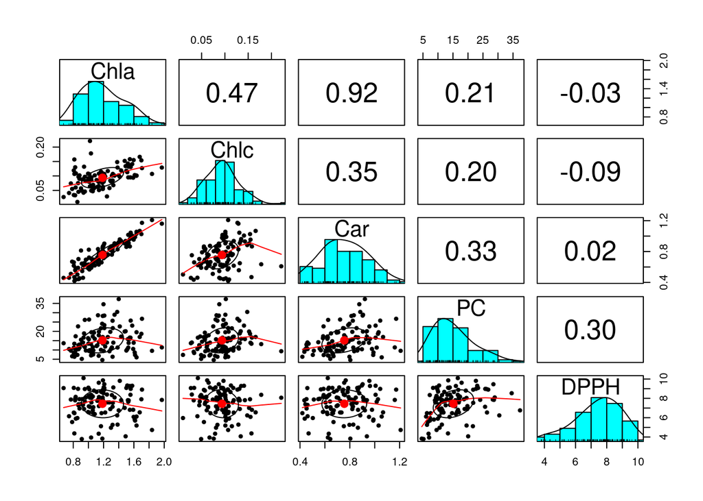

```r
pairs.panels(datos_PCA_mat[,1:5], method = "pearson")
```

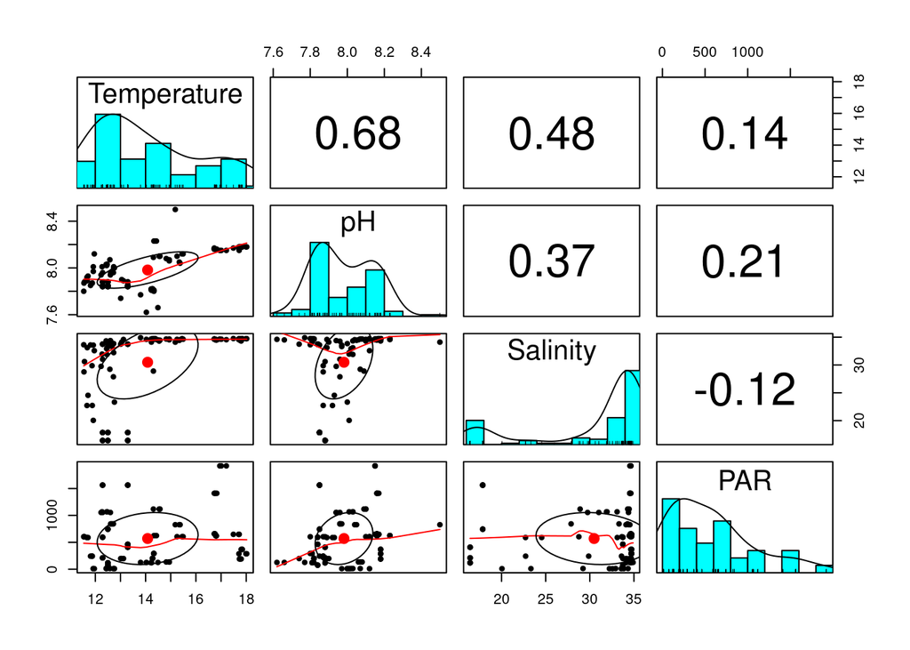

```r
pairs.panels(datos_PCA_mat[,6:9], method = "pearson")
```

# Realiza PCA

```r
PCA_Lesso <- prcomp(datos_PCA_mat, scale = TRUE)
PCA_Lesso
```

```
## Standard deviations (1, .., p=9):
## [1] 1.6906902 1.4143173 1.0817007 1.0174003 0.8313044 0.7367822 0.6898727
## [8] 0.4164170 0.2298930
##
## Rotation (n x k) = (9 x 9):
##                   PC1         PC2         PC3         PC4         PC5
## Chla        0.4568817 -0.34350662  0.22454424  0.12629866 -0.24706846
## Chlc        0.1751132 -0.51747885 -0.06730790  0.04046899  0.08370557
## Car         0.5000382 -0.24411934  0.17696923  0.15742553 -0.18111272
## PC          0.3194451 -0.03579808 -0.58459611  0.09918040  0.54291925
## DPPH        0.1367811  0.22149655 -0.67868393  0.10946599 -0.60014662
## Temperature 0.4805548  0.32225376  0.01808790  0.01615086  0.17659091
## pH          0.3229442  0.39571168  0.17996698 -0.28930770  0.29540096
## Salinity    0.1609386  0.48974551  0.27345642  0.27704648 -0.25120508
## PAR         0.1693368 -0.06321772 -0.06223532 -0.88039424 -0.25032258
##                      PC6         PC7         PC8           PC9
## Chla         0.169407469 -0.11620759  0.09036154  0.7039032070
## Chlc        -0.815836745  0.05543266 -0.09303314 -0.1051605698
## Car          0.304511115 -0.01829578  0.17626415 -0.6908936552
## PC           0.177673023  0.35675969  0.27987993  0.1146503236
## DPPH        -0.132467634 -0.28410415  0.03181368 -0.0135873412
## Temperature  0.006091989 -0.01917040 -0.79563051 -0.0038316299
## pH          -0.265955836 -0.52941888  0.42981859  0.0031091494
## Salinity    -0.302870960  0.60840260  0.23442065  0.0526626327
## PAR          0.036995683  0.35254795 -0.00638049 -0.0006879714
```